# Act_report

## Act report

In order to deliver you, dear reader of my blog, some insights about current dog rating systems on twitter, I analyzed tweets from the account WeRateDogs. According to some statements WeRateDogs is the only reliable source for dog ratings on twitter. All tweets that have been taken into account for this analysis have been created between 11/2015 and 08/2017 and contained at least one photo of a dog and an individual rating of this dog.

Based on my analysis three insights regarding the rating of dogs on twitter have been derived. First of all the number of likes for a WeRateDogs tweet (on twitter they are called favorites) and the number of retweets show a positive correlation. This means that if a specific tweet gets a higher number of likes, usually also the number of people forwarding this tweet (so called retweets) is increasing. This sounds quite logical, doesn’t it?

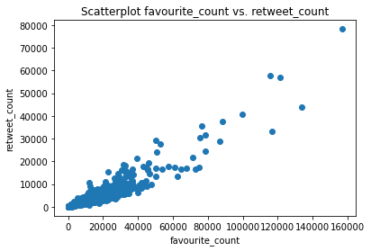

```python
import pandas as pd
import matplotlib.pyplot as plt
df1_clean = pd.read_csv('twitter_archive_master.csv')
plt.scatter(df1_clean['favourite_count'], df1_clean['retweet_count'])
plt.title('Scatterplot favourite_count vs. retweet_count')
plt.xlabel('favourite_count')
plt.ylabel('retweet_count');
```

Secondly dogs with the names 'Lucy', 'Charlie', 'Cooper', 'Oliver', 'Penny', 'Tucker', and 'Sadie' have appeared in the WeRateDogs tweets more frequently than any other dog name (dogs with these names were all rated more than 10 times). If this is due to the fact that dogs with these names are generally cuter than others or the owner of dogs with these names are more likely to send photos to WeRateDogs couldn’t be determined.

Lastly if a tweet contained a dog specified by WeRateDogs as ‘puppo’, the mean ratings were higher than for any other dog category in the account’s rating system. According to WeRateDogs the term ‘puppo’ means a dog with an age equivalent to a human teenager. This is quite astonishing as due to the cuteness factor of dog puppies (called ‘pupper’ in WeRateDog terms) one would have expected to get the highest mean ratings within this category.

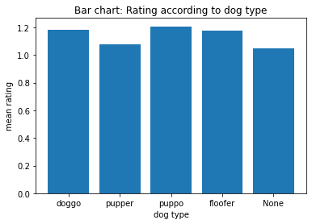

```python
dog_types = ['doggo', 'pupper', 'puppo', 'floofer', 'None']
dog_mean_ratings = [1.1853333333333331, 1.0751072961373391, 1.2080000000000002, 1.18, 1.0517412935323383]
plt.bar(dog_types, dog_mean_ratings)
plt.title('Bar chart: Rating according to dog type')
plt.xlabel('dog type')
plt.ylabel('mean rating');
```